# 简单数据分析案例

```
在本案例中，你将通过一个趣味主题来对自己所学的基础Python知识进行实践。无须担心，本项目基本使用课堂中教授的基本知识。当然了，也会有一些必要的拓展，这些新内容在下文中也会作出解释以及基本的说明。
```

## 健康指数分析 - 成为一位私人健身教练

```
众所周知，越来越多的人开始重视自己的体型与身材。如果你第一次走进健身房，健身教练肯定会带你去测量自己的一些身体指标（如身高、体重、体脂含量等等），然后根据你自己的信息来对你的健身计划作出提议。

对于绝大多数健身教练来说，他应该同时会负责好几位健身房会员。所以，一位合格的健身教练，他必须要对自己负责的会员的信息有一个把握以及汇总，才能够在接下来的训练中按情况分类，提高工作效率。

本案例便可以模拟录入会员信息并使用科学的工具将数据可视化，你在完成这些工作后，理应能够看懂各位会员的身体健康情况并作出数据的分析。
```

## Part 1 - 基本的准备

#### 在此第一部分中，你将完成工具包的引入以及一些基本的数据录入。

Let's start!

### Step 1 - 工具包的引入

#### 在本案例中，我们将使用Python自带的random库用于生成随机数据以及用于数据分析的Numpy、Pandas和用于将数据可视化的Matplotlib第三方库。

还记得如何引入库与模块吗？使用import关键字+库名就可以啦！现在我先将random模块引入项目，给他起个别名rd。

```python
import random as rd
```

再引入matplotlib，按照习惯我们只引入其中的pyplot子模块。并且添加 %matplotlib inline 语句，用于显示matplotlib生成图表。

```python
import matplotlib.pyplot as plt
%matplotlib inline
```

#### 现在你来试试将Numpy、Pandas引入，注意：为了便于后续代码的运行，我们统一给numpy起别名np，pandas起别名pd。

```python
#填写你的代码并运行
import numpy as np
import pandas as pd
```

### Step 2 - 数据的录入

#### 本小节，我们将添加自己的健康信息。但是只有这些信息肯定远远不够，考虑到当前知识的掌握程度，我们会使用随机函数再来生成一些随机的会员健康信息。

考虑到信息名以及具体的值应当一一对应（如年龄：18，身高：180），我们使用一个字典保存用户信息，再将所有个人信息存在一个列表中。

首先，作为示范，我先将自己的一些信息使用字典录入。以下代码你直接运行即可。

需要录入的信息：姓名、年龄、性别、身高、体重、肌肉量、脂肪量。

```python
health_data = {'name': 'Tony Black', 'age': 25, 'sex': 'male', 'height': 175, 'weight': 70, 'muscle': 30, 'fat': 12}
health_list = [health_data]
```

#### 尝试使用代码将这一条信息显示出来：

```python
#填写你的代码并运行
print(health_list)
```

```
[{'name': 'Tony Black', 'age': 25, 'sex': 'male', 'height': 175, 'weight': 70, 'muscle': 30, 'fat': 12}]
```

我已经将我的信息录入成功啦，你要不要来试试录入你自己的信息，加入我们的健身计划？

#### 如果你愿意，可以直接运行下面的代码哦~

```python
print('请输入每项基本信息并按回车键结束')
name = input('输入你的姓名：')
age = int(input('输入你的年龄：'))
sex = input('输入你的性别(male or female,注意大小写哦)：')
height = int(input('输入你的身高：'))
weight = int(input('输入你的体重，接受现实吧：'))
muscle = int(input('估算一下你的肌肉含量吧，一般正常身材肌肉占体重的30%~40%左右哦：'))
fat = int(input('估算一下你的脂肪含量吧，一般正常身材脂肪占体重的10%~20%左右哦：'))
```

```
请输入每项基本信息并按回车键结束
输入你的姓名：gxj
输入你的年龄：40
输入你的性别(male or female,注意大小写哦)：male
输入你的身高：179
输入你的体重，接受现实吧：85
估算一下你的肌肉含量吧，一般正常身材肌肉占体重的30%~40%左右哦：30
估算一下你的脂肪含量吧，一般正常身材脂肪占体重的10%~20%左右哦：20
```

还记得怎么将数据存储到列表中吗（可以参考上面我录入自己信息时的代码）

#### 请录入自己的数据至字典health_data中，并使用append()方法将这条新数据添加至总的信息列表health_list中。

```python
#填写你的代码并运行
health_data = {'name':name, 'age': age, 'sex':sex, 'height': height, 'weight': weight, 'muscle': muscle, 'fat': fat}
health_list.append(health_data)
```

#### 尝试使用代码分别查看自己新添加的姓名、身高以及体重信息：

```python
#填写你的代码并运行
print('姓名：{}， 身高：{}， 体重：{}'.format(health_list[-1]['name'], health_list[-1]['height'], health_list[-1]['weight']))
```

```
姓名：gxj， 身高：179， 体重：85
```

#### （选做）使用for循环并以 '键----值' 的格式输出你刚输入的这条会员的所有信息：

```python
#填写你的代码并运行
for key, value in health_list[-1].items():
    print(key,'---',value)
```

```
name --- gxj
age --- 40
sex --- male
height --- 179
weight --- 85
muscle --- 30
fat --- 20
```

#### 恭喜你！我们已经完成了一些数据的简单手工录入，相信你对列表、字典以及原始输入的方法有了一些掌握。接下来，我们将使用random模块再随机录入一些数据。首先，来介绍一下random模块中的一些我们将要用到的主要方法：

```
1、random.random

random.random()用于生成一个0到1的随机符点数: 0 <= n < 1.0

2、random.uniform

random.uniform(a, b)，用于生成一个指定范围内的随机符点数，两个参数其中一个是上限，一个是下限。如果a > b，则生成的随机数n: a <= n <= b。如果 a <b， 则 b <= n <= a

3、random.randint

random.randint(a, b)，用于生成一个指定范围内的整数。其中参数a是下限，参数b是上限，生成的随机数n: a <= n <= b

4、random.choice

random.choice从序列中获取一个随机元素。
```

#### 现在尝试使用random.randint()在0~20（包括20）之间生成一个随机数：

```python
#填写你的代码并运行
rd.randint(0,20)
```

```
5
```

是不是基本掌握了一些，接下来我将使用random.choice()生成一些随机名字。以下代码可直接运行：

```python
first = ['Jack','Jason','John','Jerry','Lucy','Lily','Ben','Lucas','Linda',
    'Cathy','Betty','Sara','Selina','Michale','Jay','Tom','Jim','Lydia',
    'Peter','Catherine','Katherine','Rich','Richard','Danny','Jane','Jenny',
    'Jemmy','Lenny','Bob','Robat','Lucky','Sky','Sun','Jacky','Jackey','Happy',
    'Apple','Michelle','Luna','Fendy','Tina','Anna','Anne','Leo','Neo','Shawn',
    'Kathy','Diana','Steve','Steven','Vicent','Kevin','Kitty','Ruby','Jessica']

second = ['Smith','Anderson','Clark','Wright','Mitchell',
    'Johnson','Thomas','Rodriguez','Lopez','Perez',
    'Williams','Jackson','Lewis','Hill','Roberts',
    'Jones','White','Lee','Scott','Turner',
    'Brown','Harris','Walker','Green','Phillips',
    'Davis','Martin','Hall','Adams','Campbell']
for i in range(10):
    rd_name = rd.choice(first)+' '+rd.choice(second)
    print(rd_name)
```

```
Sara Anderson
Diana Lee
Cathy Green
Diana Jones
Ben Martin
Jenny Anderson
Ruby Lopez
Kevin Anderson
Tom Turner
Apple Perez
```

#### 现在请你来尝试着添加150条随机会员信息并将它们添加到列表health_list中，要求原字典中的条目都有哦（包括姓名、年龄、性别、身高、体重、肌肉量、脂肪量），并满足如下条件：

1、姓名从以上first、second列表中随机组合选择

2、年龄为大于15小于60的整数

3、性别只有male和female

4、身高大于150小于200，体重大于30小于100

5、肌肉量正常为30%~45%，脂肪量为10%~20%，当然你可以随机仿真一些异常的指数来表示这位会员身体不太健康。肌肉量与脂肪量可以使用这些范围中的随机比例与体重相乘获取。

6、小数精确到小数点后一位，可使用round()函数。

```python
#填写你的代码并运行
# 通过key，value序列，使用zip方法生成字典和序列
k_name=[]
k_age=[]
k_sex=[]
k_height=[]
k_weight=[]
k_muscle=[]
k_fat=[]
for i in range(150):
    k_name.append('name')
    k_age.append('age')
    k_sex.append('sex')
    k_height.append('height')
    k_weight.append('weight')
    k_muscle.append('muscle')
    k_fat.append('fat')

v_name=[]
v_age=[]
v_sex=[]
v_height=[]
v_weight=[]
v_muscle=[]
v_fat=[]
for i in range(150):
    name=rd.choice(first)+' '+rd.choice(second)
    v_name.append(name)
    age=rd.randint(16,59)
    v_age.append(age)
    sex=rd.choice(['male','female'])
    v_sex.append(sex)
    height=rd.randint(151,200)
    v_height.append(height)
    weight=rd.randint(31,99)
    v_weight.append(weight)
    muscle=rd.randint(30,45)
    v_muscle.append(muscle)
    fat=rd.randint(10,20)
    v_fat.append(fat)

for i in range(150):
    health_data={k_name[i]:v_name[i], k_age[i]:v_age[i], k_sex[i]:v_sex[i], k_height[i]:v_height[i], k_weight[i]:v_weight[i], k_muscle[i]:v_muscle[i], k_fat[i]:v_fat[i]}
    health_list.append(health_data)
```

是否添加成功了？使用列表切片方法查看一下第3~8条会员数据吧

```python
health_list[3:9]
```

```
[{'name': 'Kathy Brown',
  'age': 21,
  'sex': 'male',
  'height': 196,
  'weight': 99,
  'muscle': 42,
  'fat': 15},
 {'name': 'Lucas Jones',
  'age': 47,
  'sex': 'male',
  'height': 183,
  'weight': 60,
  'muscle': 42,
  'fat': 16},
 {'name': 'Bob Campbell',
  'age': 52,
  'sex': 'female',
  'height': 163,
  'weight': 59,
  'muscle': 34,
  'fat': 17},
 {'name': 'Steven Davis',
  'age': 31,
  'sex': 'male',
  'height': 168,
  'weight': 80,
  'muscle': 35,
  'fat': 12},
 {'name': 'Jane Anderson',
  'age': 21,
  'sex': 'female',
  'height': 159,
  'weight': 79,
  'muscle': 38,
  'fat': 11},
 {'name': 'Jemmy Campbell',
  'age': 31,
  'sex': 'male',
  'height': 190,
  'weight': 90,
  'muscle': 43,
  'fat': 12}]
```

#### 恭喜你！完成了我们所有会员信息的录入，接下来我们将使用可视化工具来分析这些数据。

### Step3 - 数据可视化

#### 在本章，我们将展示如何将数据绘制成科学的图。大部分时间，你只需要运行我们已经编写好的代码，而你需要编写的代码并不多。我们希望，你在最后能够通过一些图找出一些规律并且能够提升一些分析能力。

首先，我们来观察一下数据中的人员组成：

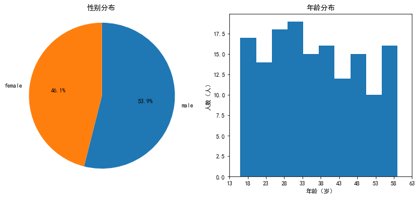

```python
# 下面语句用于生成基于health_list的遍历数据集
data_health = pd.DataFrame(health_list)

sorted_sex = data_health['sex'].value_counts()

plt.rcParams['font.sans-serif']=['SimHei']
plt.rcParams['axes.unicode_minus']=False
#解决中文乱码
plt.figure(figsize = [12, 5])

plt.subplot(1, 2, 1)
plt.pie(sorted_sex, labels = sorted_sex.index, startangle = 90,autopct='%.1f%%',counterclock = False);
plt.axis('square')
plt.title('性别分布')

plt.subplot(1, 2, 2)
x_range = np.arange(13, data_health['age'].max()+5, 5)
plt.hist(data = data_health, x = 'age')
plt.xticks(x_range, x_range)
plt.xlabel('年龄（岁）')
plt.ylabel('人数（人）')
plt.title('年龄分布')
```

我使用了饼图和直方图来完成性别与年龄的分布情况分析，相信你发现了，饼图可以展示整体与部分的关联，而直方图用于表示不同区间的分布情况。

这便是数据可视化的魅力，用两个图我也许就能获知本健身房所在的地理位置有什么特点（该地点有什么样的人口分布）。

#### 思考：你还可以从这两个图中获取什么实际信息？你可以填写在下面的留白处：

答： 1、男性比例较高。 2、年龄基本呈平均分布。

计算BMI指数：BMI指数（即身体质量指数，简称体质指数又称体重，英文为Body Mass Index，简称BMI），是用体重公斤数除以身高米数平方得出的数字，是目前国际上常用的衡量人体胖瘦程度以及是否健康的一个标准。

#### 通过计算BMI指数，我们可以得出每一位会员的健康情况，便于针对地进行训练计划的调整预指定。

#### 体质指数（BMI）=体重（kg）÷ 身高^2（m）

举例：70kg ÷（1.75×1.75）= 22.86

```
成人的BMI数值：

过轻：低于18.5

正常：18.5-23.9

过重：24-27

肥胖：28-32

非常肥胖, 高于32
```

由于存在误差，所以BMI只能作为评估个人体重和健康状况的多项标准之一。

#### （选做）请计算health_list中最后五名会员的BMI指数，并输出该指数：

```python
#填写你的代码并运行
BMI = []
for date in health_list[-5:]:
    v_BMI=date['weight']/((date['height']/100)**2)
    v_BMI=round(v_BMI,2)
    BMI.append(v_BMI)

print(BMI)
```

```
[18.17, 26.49, 28.01, 31.63, 16.95]
```

现在，我们将自动生成所有会员的BMI指数，并绘制图表示它们的分布情况：

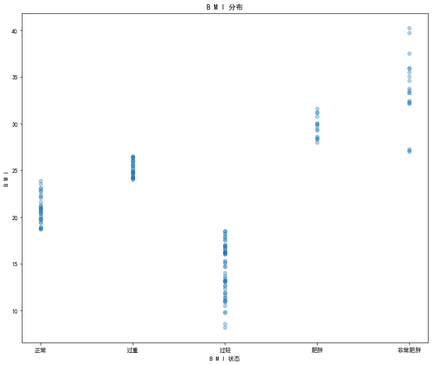

```python
def set_state(BMI):
    if BMI <= 18.5:
        return '过轻'
    elif 18.5 < BMI <= 23.9:
        return '正常'
    elif 24 < BMI <= 27:
        return '过重'
    elif 28 < BMI <= 32:
        return '肥胖'
    else:
        return '非常肥胖'

data_health['BMI'] = data_health.apply(lambda x : round(x['weight'] / (x['height']/100)**2, 2), axis=1)
data_health['BMI_state'] = data_health.apply(lambda x : set_state(x['BMI']), axis = 1)

plt.figure(figsize = [12, 10])
plt.scatter(data = data_health, x = 'BMI_state', y = 'BMI', alpha = 1/3)
plt.xlabel('B M I 状态')
plt.ylabel('B M I')
plt.title('B M I 分布')
```

在本散点图中，横轴代表会员的健康状态，纵轴代表实际的BMI指数，每个点代表一位会员的数据，颜色越深则说明该数值出现的频率越大。

#### 思考：你可以从本图中发现什么信息？你可以填写在下面的留白处：

答：

#### 本案例仅用来展示与引导学生发现Python的能力与魅力，然而数据采用随机生成，会有不切合生活实际分布的情况发生，结合篇幅与内容，不再深入分析更多。

#### 思考：如果此时有一个完整的真实的健身房会员数据集放在你面前，你还想从中分析或总结出什么信息？你可以填写在下面的留白处：

答：